# DA410_Exam2_MattGraham

```r
library(nnspat)  # used for dist2full()
library("dplyr")  # used to select numeric datatypes
library("ggplot2")
library(reshape)  # used for melting matricies
library(klaR)
library(ggvis)
library(class)
library(gmodels)
library(MASS)
library(readxl)
library(psych)
library(corrplot)
library(lavaan)
library(semPlot)
library(semTable)
library(kutils)
```

## Problem 1

Get data

```r
cov.mat <- data.frame(c(5, 0, 0), c(0, 9,0), c(0,0,9))
cov.mat
```

| c.5..0..0. | c.0..9..0. | c.0..0..9. |
| --- | --- | --- |
| 5 | 0 | 0 |
| 0 | 9 | 0 |
| 0 | 0 | 9 |

### A) Find eigenvalues and vectors

```r
cov.mat.vals <- eigen(cov.mat)$values
cov.mat.vals
```

```
## [1] 9 9 5
```

```r
cov.mat.vects <- eigen(cov.mat)$vectors
cov.mat.vects
```

```
##      [,1] [,2] [,3]
## [1,]    0    0    1
## [2,]    0    1    0
## [3,]    1    0    0
```

### B) Find variance explained

```r
for (r in cov.mat.vals) {
  print(r/sum(cov.mat.vals))
}
```

```
## [1] 0.3913043
## [1] 0.3913043
## [1] 0.2173913
```

We can see that of our eigen values, ~80% of our variance is explained with 2 dimensions, while ~20% is explained with 1 dimension. This can be seen below.

#### Plot

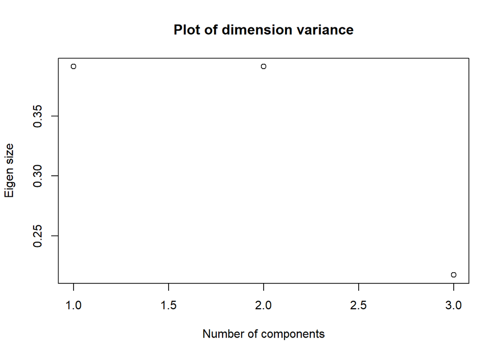

```r
plot(cov.mat.vals/sum(cov.mat.vals), xlab = 'Number of components', ylab='Eigen size', main='Plot of dimension variance')
```

## Problem 2

Assumption check:

Variables used should be metric. Dummy variables can also be considered, but only in special cases. -> check

Sample size: Sample size should be more than 200. -> check

Homogeneous sample: A sample should be homogenous. Violation of this assumption increases the sample size as the number of variables increases. Reliability analysis is conducted to check the homogeneity between variables.

Correlation: At least 0.30 correlations are required between the research variables.

```r
french <- c(1, .44, .41, .29, .33, .25)
english <- c(.44, 1, .35, .35, .32, .33)
history <- c(.41, .35, 1, .16, .19, .18)
arithmetic <- c(.29, .35, .16, 1, .59, .47)
algebra <- c(.33, .32, .19, .59, 1, .46)
geometry <- c(.25, .33, .18, .47, .46, 1)

subject.cor <- cbind(french, english, history, arithmetic, algebra, geometry)
row.names(subject.cor) <- c('french', 'english', 'history', 'arithmetic', 'algebra', 'geometry')
as.data.frame(subject.cor)
```

|  | french | english | history | arithmetic | algebra | geometry |
| --- | --- | --- | --- | --- | --- | --- |
| french | 1.00 | 0.44 | 0.41 | 0.29 | 0.33 | 0.25 |
| english | 0.44 | 1.00 | 0.35 | 0.35 | 0.32 | 0.33 |
| history | 0.41 | 0.35 | 1.00 | 0.16 | 0.19 | 0.18 |
| arithmetic | 0.29 | 0.35 | 0.16 | 1.00 | 0.59 | 0.47 |
| algebra | 0.33 | 0.32 | 0.19 | 0.59 | 1.00 | 0.46 |
| geometry | 0.25 | 0.33 | 0.18 | 0.47 | 0.46 | 1.00 |

We have a few correlations that are unable to be compared, and will be noted through analysis

Since we do not have a raw dataset, we assume there are no outliers.

### Running fa

```r
solution <- fa(r = subject.cor, nfactors = 2, rotate = "oblimin", fm="pa")
solution
```

```
## Factor Analysis using method =  pa
## Call: fa(r = subject.cor, nfactors = 2, rotate = "oblimin", fm = "pa")
## Standardized loadings (pattern matrix) based upon correlation matrix
##             PA1   PA2   h2   u2 com
## french     0.59  0.37 0.49 0.51 1.7
## english    0.59  0.23 0.41 0.59 1.3
## history    0.43  0.41 0.36 0.64 2.0
## arithmetic 0.71 -0.34 0.62 0.38 1.4
## algebra    0.70 -0.27 0.56 0.44 1.3
## geometry   0.58 -0.18 0.38 0.62 1.2
##
##                        PA1  PA2
## SS loadings           2.22 0.59
## Proportion Var        0.37 0.10
## Cumulative Var        0.37 0.47
## Proportion Explained  0.79 0.21
## Cumulative Proportion 0.79 1.00
##
## Mean item complexity =  1.5
## Test of the hypothesis that 2 factors are sufficient.
##
## The degrees of freedom for the null model are  15  and the objective function was  1.43
## The degrees of freedom for the model are 4  and the objective function was  0.01
##
## The root mean square of the residuals (RMSR) is  0.01
## The df corrected root mean square of the residuals is  0.03
##
## Fit based upon off diagonal values = 1
## Measures of factor score adequacy
##                                                    PA1  PA2
## Correlation of (regression) scores with factors   0.90 0.73
## Multiple R square of scores with factors          0.82 0.53
## Minimum correlation of possible factor scores     0.63 0.06
```

## Problem 3

Get data

```r
food.stuff <- read.table("C:/mattgraham93.github.io/school/22_3_DA410/data/foodstuff.dat", header=TRUE)
food.stuff <- food.stuff[-1]
food.stuff
```

| Energy | Protein | Fat | Calcium | Iron |
| --- | --- | --- | --- | --- |
| 340 | 20 | 28 | 9 | 2.6 |
| 245 | 21 | 17 | 9 | 2.7 |
| 420 | 15 | 39 | 7 | 2.0 |
| 375 | 19 | 32 | 9 | 2.5 |
| 180 | 22 | 10 | 17 | 3.7 |
| 115 | 20 | 3 | 8 | 1.4 |
| 170 | 25 | 7 | 12 | 1.5 |
| 160 | 26 | 5 | 14 | 5.9 |
| 265 | 20 | 20 | 9 | 2.6 |
| 300 | 18 | 25 | 9 | 2.3 |

[output cut: 17 more lines]

### a. Determine factors to use

```r
library(factoextra)
```

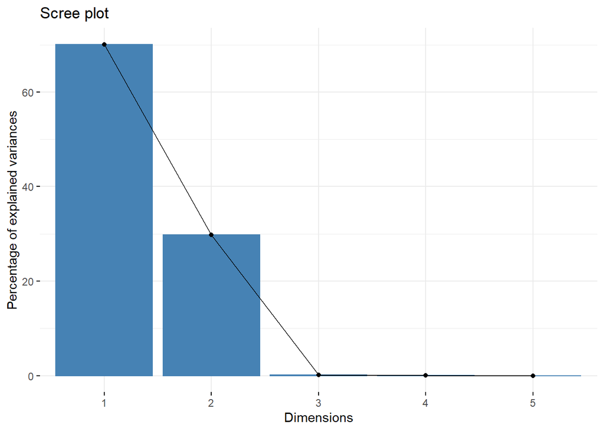

```r
food.stuff.pca <- prcomp(food.stuff)
fviz_eig(food.stuff.pca)
```

We will ultimately use 2 dimensions when concluding our analysis.

### B - obtaining loadings

```r
S <- cov(food.stuff)
R <- cor(food.stuff)
```

S

```r
as.data.frame(S)
```

|  | Energy | Protein | Fat | Calcium | Iron |
| --- | --- | --- | --- | --- | --- |
| Energy | 10243.01994 | 74.807692 | 1124.5655271 | -2530.292023 | -14.7521368 |
| Protein | 74.80769 | 18.076923 | 1.1923077 | -28.230769 | -1.0846154 |
| Fat | 1124.56553 | 1.192308 | 126.7207977 | -270.673789 | -0.9965812 |
| Calcium | -2530.29202 | -28.230769 | -270.6737892 | 6089.344729 | 5.0491453 |
| Iron | -14.75214 | -1.084615 | -0.9965812 | 5.049145 | 2.1341026 |

R

```r
as.data.frame(R)
```

|  | Energy | Protein | Fat | Calcium | Iron |
| --- | --- | --- | --- | --- | --- |
| Energy | 1.00000000 | 0.17384812 | 0.98706740 | -0.32038440 | -0.09977765 |
| Protein | 0.17384812 | 1.00000000 | 0.02491163 | -0.08508934 | -0.17462478 |
| Fat | 0.98706740 | 0.02491163 | 1.00000000 | -0.30813212 | -0.06060118 |
| Calcium | -0.32038440 | -0.08508934 | -0.30813212 | 1.00000000 | 0.04429196 |
| Iron | -0.09977765 | -0.17462478 | -0.06060118 | 0.04429196 | 1.00000000 |

Get eigenvalues and eigenvectors of S and R

```r
eig.S <- eigen(S)
eig.R <- eigen(R)
```

Eigen S

```r
eig.S
```

```
## eigen() decomposition
## $values
## [1] 1.155253e+04 4.903923e+03 2.042503e+01 2.066907e+00 3.516836e-01
##
## $vectors
##              [,1]          [,2]         [,3]          [,4]          [,5]
## [1,]  0.901061141  0.4195897978 -0.034918237 -0.0089992248  0.1035999595
## [2,]  0.006887716  0.0011983568 -0.924379029  0.1023111641 -0.3674329322
## [3,]  0.098689332  0.0474125325  0.374781853  0.0877224332 -0.9164364709
## [4,] -0.422255831  0.9064738840 -0.002194532 -0.0001874493  0.0005097596
## [5,] -0.001344580 -0.0003389534  0.061950579  0.9908361011  0.1200167645
```

Eigen R

```r
eig.R
```

```
## eigen() decomposition
## $values
## [1] 2.197777619 1.144204758 0.848574671 0.807842783 0.001600169
##
## $vectors
##            [,1]        [,2]       [,3]      [,4]         [,5]
## [1,] -0.6539155  0.08725829 -0.1490040 0.1985936  0.709322816
## [2,] -0.1511882 -0.69052953  0.4629211 0.5245825 -0.104059181
## [3,] -0.6394332  0.20196122 -0.2157528 0.1336768 -0.697078234
## [4,]  0.3546581 -0.00633049 -0.6521357 0.6699900  0.003161132
## [5,]  0.1219811  0.68900403  0.5400663 0.4675657  0.010235855
```

```r
for (r in eig.R$values) {
  print(r/sum(eig.R$values))
}
```

```
## [1] 0.4395555
## [1] 0.228841
## [1] 0.1697149
## [1] 0.1615686
## [1] 0.0003200338
```

We can see that of our eigen values, ~65% of our variance is explained with just two dimensions, and inerestingly enough going with all 5 shows almost no meaningful value. We can see this below.

#### Plot

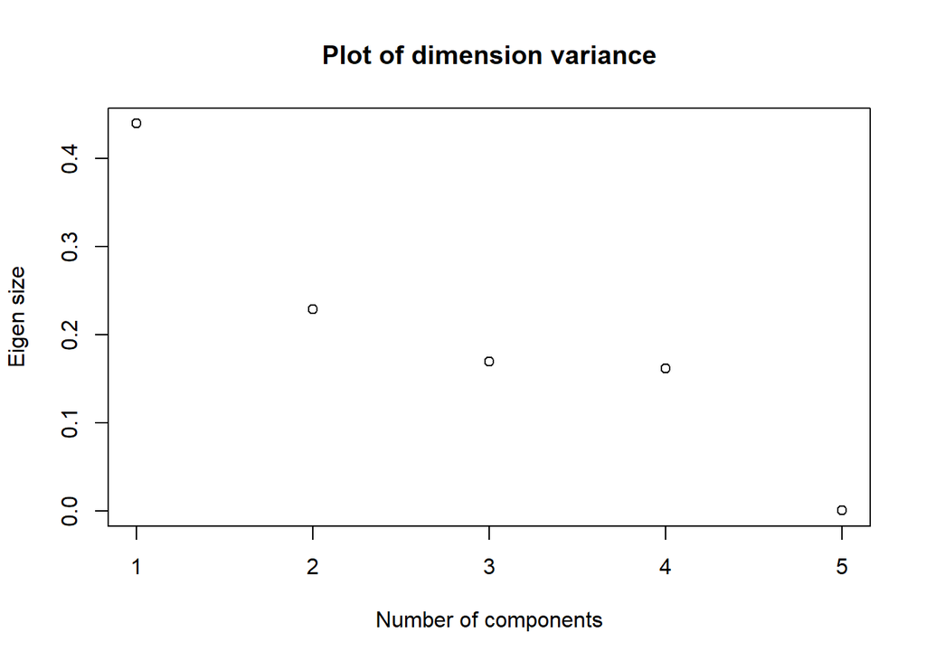

```r
plot(eig.R$values/sum(eig.R$values), xlab = 'Number of components', ylab='Eigen size', main='Plot of dimension variance')
```

## Problem 4

```r
scores <- read.table("C:/mattgraham93.github.io/school/22_3_DA410/data/test_score.dat", header=TRUE)
scores <- scores[-1]
scores
```

| math | reading | sex |
| --- | --- | --- |
| 83.16 | 79.67 | boy |
| 102.51 | 101.13 | boy |
| 81.63 | 80.53 | boy |
| 88.25 | 84.58 | boy |
| 81.47 | 76.52 | boy |
| 87.19 | 84.70 | boy |
| 88.66 | 85.86 | boy |
| 79.35 | 81.03 | boy |
| 83.35 | 80.44 | boy |
| 86.58 | 84.67 | boy |

[output cut: 52 more lines]

### Hotelling’s test

```r
summary(manova(cbind(math, reading) ~sex, data=scores), test="Hotelling")
```

```
##           Df Hotelling-Lawley approx F num Df den Df    Pr(>F)
## sex        1          0.30593   9.0249      2     59 0.0003805 ***
## Residuals 60
## ---
## Signif. codes:  0 '***' 0.001 '**' 0.01 '*' 0.05 '.' 0.1 ' ' 1
```

#### Hotelling’s Analysis

At alpha = 0.05 and p-value < 0.05, we can conclude there is sufficient evidence to state there are differences between mean math and reading scores between the recorded sexes.

## Problem 5

Get data

```r
glucose <- read.table("C:/mattgraham93.github.io/school/22_3_DA410/data/T3_5_DIABETES.DAT", header=FALSE)[1:34,]
glucose <- glucose[-1]
colnames(glucose) <- c('rel_wt', 'fst_pls_glu', 'gl_int', 'ins_resp', 'ins_resist')

ys <- glucose[1:2]
xs <- glucose[3:5]

glucose
```

|  | rel_wt | fst_pls_glu | gl_int | ins_resp | ins_resist |
| --- | --- | --- | --- | --- | --- |
| 1 | 0.81 | 80 | 356 | 124 | 55 |
| 2 | 0.95 | 97 | 289 | 117 | 76 |
| 3 | 0.94 | 105 | 319 | 143 | 105 |
| 4 | 1.04 | 90 | 356 | 199 | 108 |
| 5 | 1.00 | 90 | 323 | 240 | 143 |
| 6 | 0.76 | 86 | 381 | 157 | 165 |
| 7 | 0.91 | 100 | 350 | 221 | 119 |
| 8 | 1.10 | 85 | 301 | 186 | 105 |
| 9 | 0.99 | 97 | 379 | 142 | 98 |
| 10 | 0.78 | 97 | 296 | 131 | 94 |

[output cut: 24 more lines]

Find means

```r
x.bar <- colMeans(xs)
x.bar
```

```
##     gl_int   ins_resp ins_resist
##  341.47059  175.32353   99.11765
```

```r
y.bar <- colMeans(ys)
y.bar
```

```
##      rel_wt fst_pls_glu
##   0.9164706  89.6470588
```

### a - Find canonical correlations

```r
cancor2<-function(x,y,dec=4){
#Canonical Correlation Analysis to mimic SAS PROC CANCOR output.
#Basic formulas can be found in Chapter 10 of Mardia, Kent, and Bibby (1979).
# The approximate F statistic is exercise 3.7.6b.
    x<-as.matrix(x)
    y<-as.matrix(y)

    n<-dim(x)[1]
    q1<-dim(x)[2]
    q2<-dim(y)[2]
    q<-min(q1,q2)

    S11<-cov(x)
    S12<-cov(x,y)
    S21<-t(S12)
    S22<-cov(y)

    E1<-eigen(solve(S11)%*%S12%*%solve(S22)%*%S21)
    E2<-eigen(solve(S22)%*%S21%*%solve(S11)%*%S12)

    rsquared<-as.double(E1$values[1:q])

    LR<-NULL;pp<-NULL;qq<-NULL;tt<-NULL

    for (i in 1:q){
        LR<-c(LR,prod(1-rsquared[i:q]))
        pp<-c(pp,q1-i+1)
        qq<-c(qq,q2-i+1)
        tt<-c(tt,n-1-i+1)}

    m<-tt-0.5*(pp+qq+1);lambda<-(1/4)*(pp*qq-2);s<-sqrt((pp^2*qq^2-4)/(pp^2+qq^2-5))
    F<-((m*s-2*lambda)/(pp*qq))*((1-LR^(1/s))/LR^(1/s))
    df1<-pp*qq;df2<-(m*s-2*lambda)
    pval<-1-pf(F,df1,df2)
    outmat<-round(cbind(sqrt(rsquared),rsquared,LR,F,df1,df2,pval),dec)

    colnames(outmat) <- list("R","RSquared","LR","ApproxF","NumDF","DenDF","pvalue")
    rownames(outmat) <- as.character(1:q)
    xrels<-round(cor(x,x%*%E1$vectors)[,1:q],dec)
    colnames(xrels)<-apply(cbind(rep("U",q),as.character(1:q)),1,paste,collapse="")
    yrels<-round(cor(y,y%*%E2$vectors)[,1:q],dec)
    colnames(yrels)<- apply(cbind(rep("V",q),as.character(1:q)),1,paste,collapse="")
    list(Summary=outmat,
         a.Coefficients=E1$vectors,
         b.Coefficients=E2$vectors,
         XUCorrelations=xrels,YVCorrelations=yrels
     )
   }
## END FUNCTION
#################################################
```

### b - Find standard coefficients

For canonical variables

Fasting coefficients

```r
before.coefficients <- cancor2(xs, ys)$a.Coefficients
after.coefficients <- cancor2(xs, ys)$b.Coefficients

diag(before.coefficients)
```

```
## [1] 0.42680635 0.07577154 0.27703237
```

Post-consumption coefficients

```r
diag(after.coefficients)
```

```
## [1] 0.99999176 0.09433123
```

### c - Test significance for reach canonical correlation

```r
cancor2(xs, ys)
```

```
## $Summary
##        R RSquared     LR ApproxF NumDF DenDF pvalue
## 1 0.6024   0.3628 0.6353  2.4616     6    58 0.0345
## 2 0.0546   0.0030 0.9970     NaN     2   NaN    NaN
##
## $a.Coefficients
##            [,1]        [,2]       [,3]
## [1,]  0.4268063 -0.96431194 0.06551464
## [2,] -0.5231307  0.07577154 0.95862448
## [3,]  0.7376792  0.25369501 0.27703237
##
## $b.Coefficients
##              [,1]       [,2]
## [1,]  0.999991761 0.99554087
## [2,] -0.004059221 0.09433123
##
## $XUCorrelations
##                 U1      U2
## gl_int      0.2754 -0.9065
## ins_resp   -0.2448 -0.0518
## ins_resist  0.7781  0.3186
##
## $YVCorrelations
##                  V1     V2
## rel_wt       0.9691 0.2465
## fst_pls_glu -0.1661 0.9861
```

```r
# It produces two other pieces of information:  An F-test for the
# significance of each canonical correlation, and the correlations between
# the original variables and the corresponding canonical variates.
```

## Problem 6

```r
hematology <- read.csv('C:/mattgraham93.github.io/school/22_3_DA410/data/hematology.csv', header=TRUE)
hematology
```

| Observation.number | X..1 | X..2 | X..3 | X..4 | X..5 | X..6 |
| --- | --- | --- | --- | --- | --- | --- |
| 1 | 13.4 | 39 | 4100 | 14 | 25 | 17 |
| 2 | 14.6 | 46 | 5000 | 15 | 30 | 20 |
| 3 | 13.5 | 42 | 4500 | 19 | 21 | 18 |
| 4 | 15.0 | 46 | 4600 | 23 | 16 | 18 |
| 5 | 14.6 | 44 | 5100 | 17 | 31 | 19 |
| 6 | 14.0 | 44 | 4900 | 20 | 24 | 19 |
| 7 | 16.4 | 49 | 4300 | 21 | 17 | 18 |
| 8 | 14.8 | 44 | 4400 | 16 | 26 | 29 |
| 9 | 15.2 | 46 | 4100 | 27 | 13 | 27 |
| 10 | 15.5 | 48 | 8400 | 34 | 42 | 36 |

[output cut: 5 more lines]

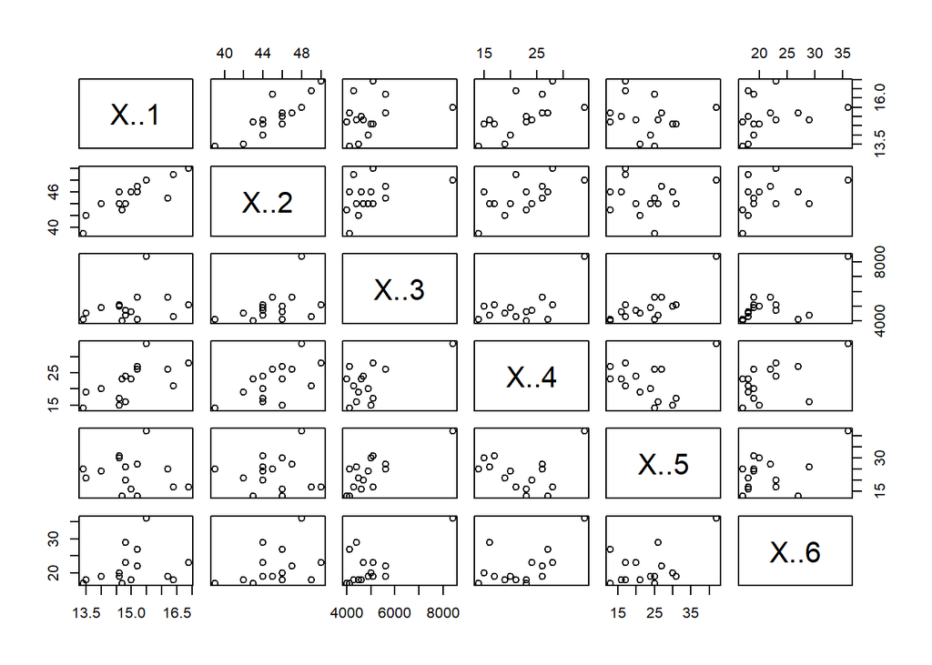

```r
pairs(hematology[-1])
```

Normalizing

```r
z <- hematology[,-c(1,1)]
means <- apply(z,2,mean)
sds <- apply(z,2,sd)
nor <- scale(z,center=means,scale=sds)

distance = dist(nor)
```

Plotting

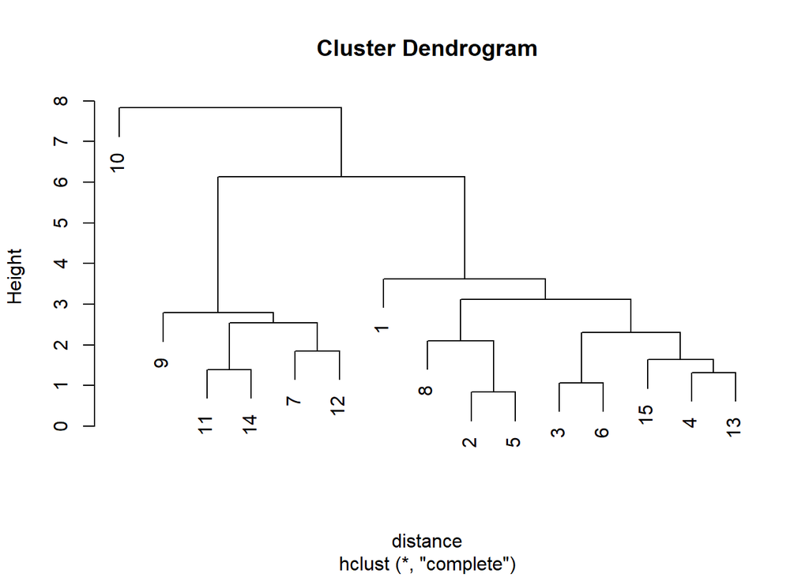

```r
mydata.hclust = hclust(distance)
plot(mydata.hclust)
```

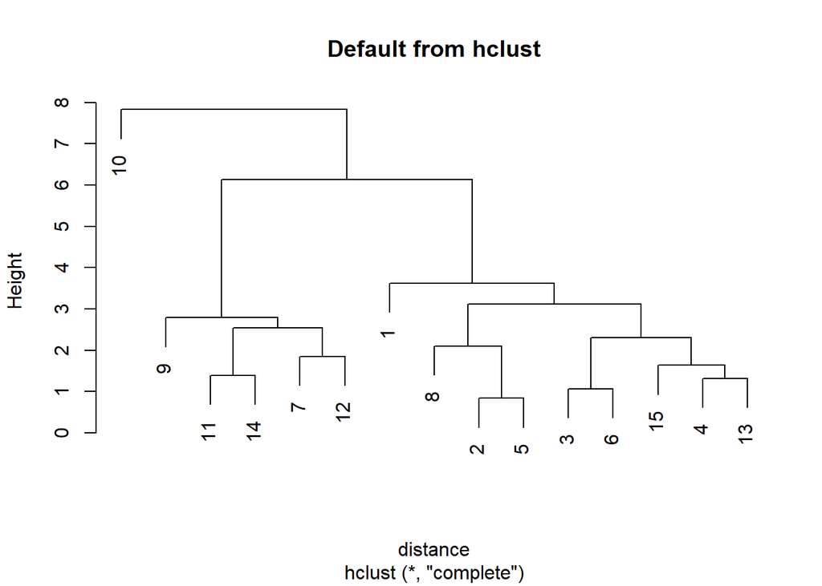

```r
plot(mydata.hclust,labels=hematology$Observation.number,main='Default from hclust')
```

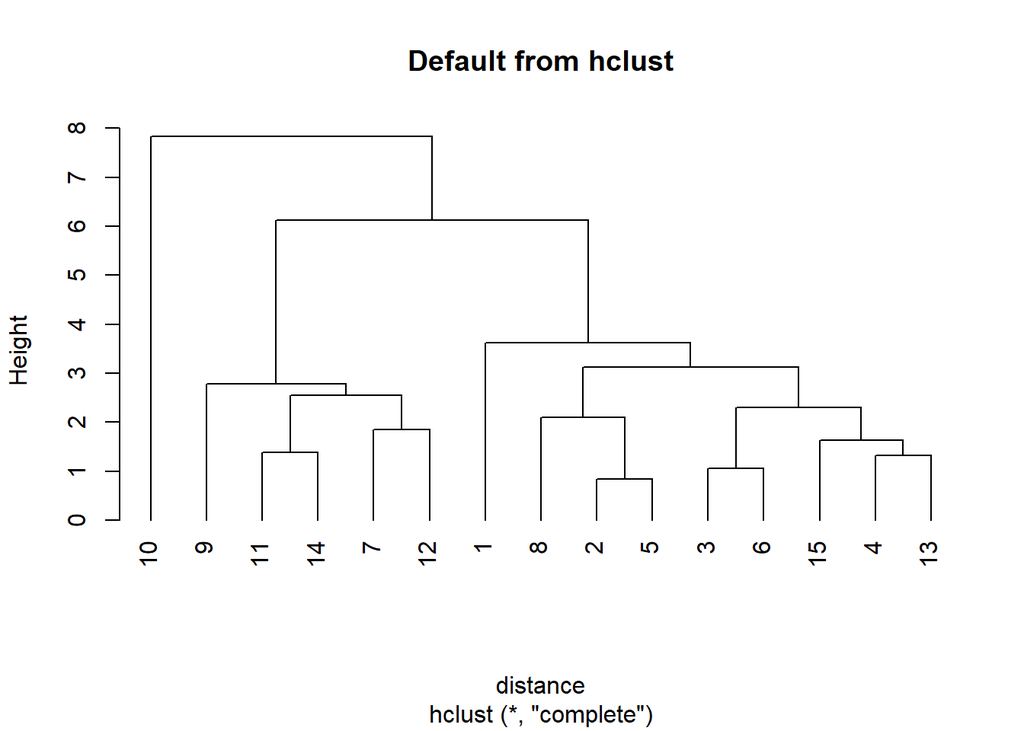

```r
plot(mydata.hclust,hang=-1, labels=hematology$Observation.number,main='Default from hclust')
```

Average linkage

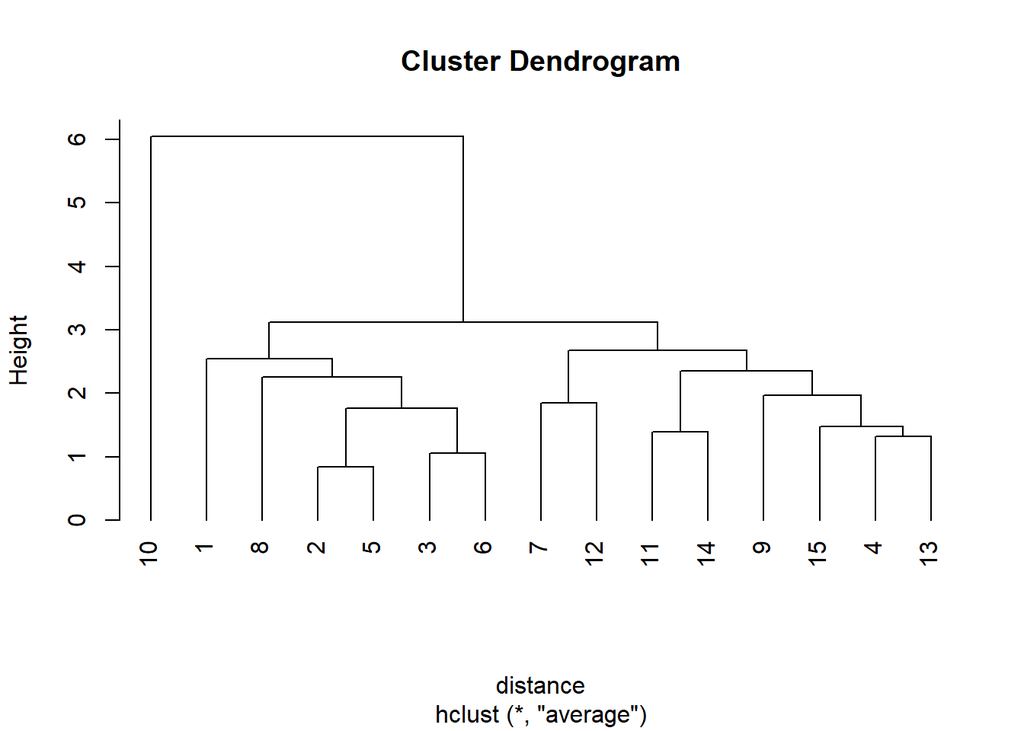

```r
mydata.hclust<-hclust(distance,method="average")
plot(mydata.hclust,hang=-1)
```